# Homework - Confidence Intervals

# MVP

Now we’ll go back to CI creation in the normal fashion. We’ll take the `ames` data from the CIs lab earlier today and regard it now as a **sample**, we won’t be drawing any smaller samples from within it. This is the usual situation in an analysis: you use all the data available to you!

**Task 1.**  
Load the data again, `clean_names()`, and re-familiarise yourself with it

**Ans 1.**

Load libraries:

```r
library(tidyverse)
library(infer)
library(janitor)
```

Load and explore the data held in ames.csv

```r
ames <- read_csv("data/ames.csv") %>%
  clean_names()
```

```r
glimpse(ames)
```

```
Rows: 2,930
Columns: 82
$ order           <dbl> 1, 2, 3, 4, 5, 6, 7, 8, 9, 10, 11, 12, 13, 14, 15, 16, 17, 18, 19, 20, 21, 22, 23, 24, 25, 26, 27, 28, 29, 30~
$ pid             <dbl> 526301100, 526350040, 526351010, 526353030, 527105010, 527105030, 527127150, 527145080, 527146030, 527162130,~
$ ms_sub_class    <dbl> 20, 20, 20, 20, 60, 60, 120, 120, 120, 60, 60, 20, 60, 20, 120, 60, 50, 20, 20, 20, 20, 85, 60, 20, 20, 20, 2~
$ ms_zoning       <chr> "RL", "RH", "RL", "RL", "RL", "RL", "RL", "RL", "RL", "RL", "RL", "RL", "RL", "RL", "RL", "RL", "RL", "RL", "~
$ lot_frontage    <dbl> 141, 80, 81, 93, 74, 78, 41, 43, 39, 60, 75, NA, 63, 85, NA, 47, 152, 88, 140, 85, 105, 85, NA, NA, NA, 65, 7~
$ lot_area        <dbl> 31770, 11622, 14267, 11160, 13830, 9978, 4920, 5005, 5389, 7500, 10000, 7980, 8402, 10176, 6820, 53504, 12134~
$ street          <chr> "Pave", "Pave", "Pave", "Pave", "Pave", "Pave", "Pave", "Pave", "Pave", "Pave", "Pave", "Pave", "Pave", "Pave~
$ alley           <chr> NA, NA, NA, NA, NA, NA, NA, NA, NA, NA, NA, NA, NA, NA, NA, NA, NA, NA, NA, NA, NA, NA, NA, NA, NA, NA, NA, N~
$ lot_shape       <chr> "IR1", "Reg", "IR1", "Reg", "IR1", "IR1", "Reg", "IR1", "IR1", "Reg", "IR1", "IR1", "IR1", "Reg", "IR1", "IR2~
$ land_contour    <chr> "Lvl", "Lvl", "Lvl", "Lvl", "Lvl", "Lvl", "Lvl", "HLS", "Lvl", "Lvl", "Lvl", "Lvl", "Lvl", "Lvl", "Lvl", "HLS~
$ utilities       <chr> "AllPub", "AllPub", "AllPub", "AllPub", "AllPub", "AllPub", "AllPub", "AllPub", "AllPub", "AllPub", "AllPub",~
$ lot_config      <chr> "Corner", "Inside", "Corner", "Corner", "Inside", "Inside", "Inside", "Inside", "Inside", "Inside", "Corner",~
$ land_slope      <chr> "Gtl", "Gtl", "Gtl", "Gtl", "Gtl", "Gtl", "Gtl", "Gtl", "Gtl", "Gtl", "Gtl", "Gtl", "Gtl", "Gtl", "Gtl", "Mod~
```

[output cut: 69 more lines]

Check data for NA values

```r
ames %>%
  summarise(across(.cols = everything(),
                   .fns = ~sum(is.na(.x))))
```

| order | pid | ms_sub_class | ms_zoning | lot_frontage | lot_area | street | alley | lot_shape | land_contour | utilities | lot_config | land_slope | neighborhood | condition_1 | condition_2 | bldg_type | house_style | overall_qual | overall_cond | year_built | year_remod_add | roof_style | roof_matl | exterior_1st | exterior_2nd | mas_vnr_type | mas_vnr_area | exter_qual | exter_cond | … |
| --- | --- | --- | --- | --- | --- | --- | --- | --- | --- | --- | --- | --- | --- | --- | --- | --- | --- | --- | --- | --- | --- | --- | --- | --- | --- | --- | --- | --- | --- | --- |
| 0 | 0 | 0 | 0 | 490 | 0 | 0 | 2732 | 0 | 0 | 0 | 0 | 0 | 0 | 0 | 0 | 0 | 0 | 0 | 0 | 0 | 0 | 0 | 0 | 0 | 0 | 23 | 23 | 0 | 0 | … |

```r
NA
```

**Task 2.**  
Investigate the distribution of `lot_area`. Is the distribution roughly normal? If not, what problems do you find?

**Ans 2.**

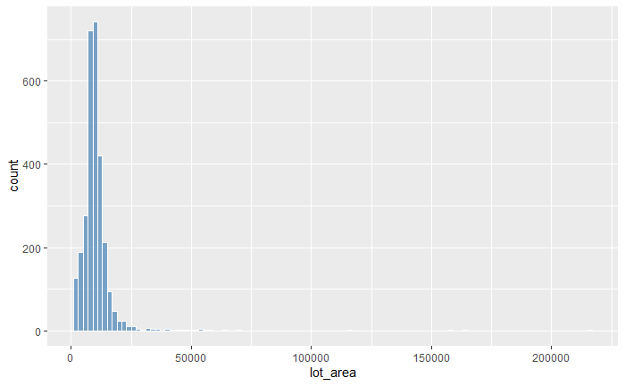

```r
ames %>%
  ggplot(aes(x = lot_area)) +
  geom_histogram(col = "white", fill = "steel blue", alpha = 0.7, binwidth = 2000)
```

The distribution is not normal. There’s a significant right-skew.

**Task 3.**  
Compute and visualise a bootstrap sampling distribution for the `mean(lot_area)` of the sold houses.

**Ans 3.**

```r
# specify that we want to look at lot_area variable, 5000 reps, and want to calculate the mean
bootstrap_sample <- ames %>%
  specify(response = lot_area) %>%
  generate(reps = 5000, type = "bootstrap") %>%
  calculate(stat = "mean")
```

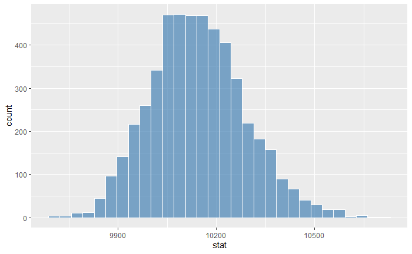

```r
bootstrap_sample %>%
  ggplot(aes(x = stat)) +
  geom_histogram(col = "white", fill = "steel blue", alpha = 0.7)
```

**Task 4.**  
Use your bootstrap distribution to calculate a $95\%$ CI for `mean(lot_area)`, and visualise it on the distribution

**Ans 4.**

```r
infer_ci_95 <- bootstrap_sample %>%
  get_confidence_interval(level = 0.95, type = "percentile")

infer_ci_95
```

| lower_ci | upper_ci |
| --- | --- |
| 9879.677 | 10443.52 |

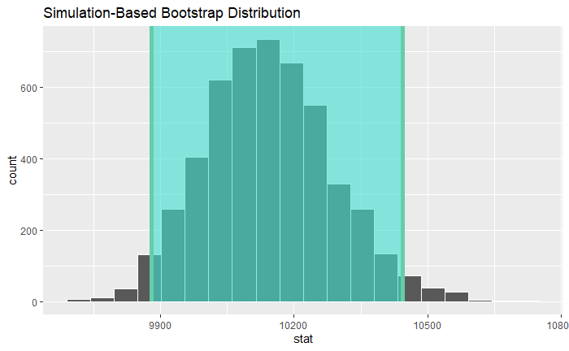

```r
bootstrap_sample %>%
  visualise(bin = 20) +
  shade_confidence_interval(endpoints = infer_ci_95)
```

**Task 5.**  
You would like to know the `mean(lot_area)` of the sold houses with higher confidence. Calculate the $99\%$ CI for this variable (you can re-use your bootstrap distribution from above). Is it narrower or broader than the $95\%$ CI? Does that make sense?

**Ans 5.**

```r
infer_ci_99 <- bootstrap_sample %>%
  get_confidence_interval(level = 0.99, type = "percentile")

infer_ci_99
```

| lower_ci | upper_ci |
| --- | --- |
| 9817.07 | 10558.82 |

The $99\%$ CI is wider than the $95\%$ CI. The bounds have moved away from the mean lot area.

**Task 6.**  
Calculate the point estimate of the `mean(lot_area)`

**Ans 6.**

```r
bootstrap_sample %>%
  summarise(mean_lot_area = mean(stat))
```

| mean_lot_area |
| --- |
| 10143.9 |

# Extension

**Task 1.**  
Calculate a point estimate and $95\%$ CI for the proportion of houses in the data built before 1920. Does the number of `reps` you use matter? [Investigate `reps` from $200$ up to $50000$, memory of your laptop permitting].

**Ans.** Calculation of point estimate from original sample (in this exercise, it’s the population)

```r
ames %>%
  mutate(house_built_flag = if_else(year_built < 1920, "before_1920", "after_1920")) %>%
  summarise(prop_built_before_1920 = mean(house_built_flag == "before_1920"))
```

| prop_built_before_1920 |
| --- |
| 0.06006826 |

```r
# specify that we want to look at house_built_flag, for 200, 500, 1000, 2000, 5000, 10000, 20000, 50000 reps, and want to calculate the mean

results_reps <- tibble()

for (resamples_num in c(200, 500, 1000, 2000, 5000, 10000, 20000, 50000)){

  bootstrap_sample_rep <- ames %>%
  mutate(house_built_flag = if_else(year_built < 1920, "before_1920", "after_1920")) %>%
  specify(response = house_built_flag, success = "before_1920") %>%
  generate(reps = resamples_num, type = "bootstrap") %>%
  calculate(stat = "prop")

  infer_ci_95 <- bootstrap_sample_rep %>%
  get_confidence_interval(level = 0.95, type = "percentile")

  # bootstrap_sample_rep %>%
  # summarise(point_est = mean(stat))

  # prepare new row for results, storing CI bounds
  this_result <- c(
    resamples= resamples_num,
    point_est = mean(bootstrap_sample_rep$stat),
    lower_bound = infer_ci_95 %>%
      pull(lower_ci),
    upper_bound = infer_ci_95 %>%
      pull(upper_ci),
    ci_width = infer_ci_95 %>% pull(upper_ci) - infer_ci_95 %>% pull(lower_ci)
  )


  # add this_result to growing tibble of results
  results_reps <- results_reps %>%
    bind_rows(this_result)


}

results_reps
```

| resamples | point_est | lower_bound | upper_bound | ci_width |
| --- | --- | --- | --- | --- |
| 200 | 0.05975597 | 0.05153584 | 0.06792662 | 0.01639078 |
| 500 | 0.05982730 | 0.05187713 | 0.06843857 | 0.01656143 |
| 1000 | 0.05984812 | 0.05118601 | 0.06860922 | 0.01742321 |
| 2000 | 0.06009266 | 0.05153584 | 0.06860068 | 0.01706485 |
| 5000 | 0.06004778 | 0.05153584 | 0.06860068 | 0.01706485 |
| 10000 | 0.06004867 | 0.05153584 | 0.06860068 | 0.01706485 |
| 20000 | 0.06012995 | 0.05153584 | 0.06860068 | 0.01706485 |
| 50000 | 0.06003965 | 0.05187713 | 0.06894198 | 0.01706485 |